# Introduction to GIS in R

```r
library(sp) # this is an older, slower and murkier spatial library
library(raster)
library(rgeos)
# https://stackoverflow.com/questions/51566741/updating-rgdal-in-r-3-5-1-c11-dependency-although-c11-is-available
library(rgdal)
library(leaflet)
# sudo apt-get install libudunits2-dev
# sudo apt-get install libgeos-3.7.0 libgeos-dev
# sudo ln -s /usr/lib/x86_64-linux-gnu/libhdf5_cpp.so /usr/lib/x86_64-linux-gnu/libhdf5_cpp.so.103
library(sf) # this is the more modern and effective version of sp
library(magrittr) # this is for piping
library(ggplot2)
library(dplyr) # this is for manipulating data
library(geojsonsf)
```

In many scenarios, either in simulations or when working with real-world data, it may be necessary to use concepts from geometry when programming. In the following, we are going to have a look at some possible cases, and in the second half of the notebook, we are going to add geometries to maps created from several input formats.

## Computer representation of geometric objects

First of all, we have to look at the fundamental building blocks of our spatial data. When we work with coordinates or boundaries of administrative units, we expect that the computer knows how to answer some very natural questions. Some examples are:

- Does a certain administrative unit contain a pair of coordinates?
- How long is a given road?
- What is the area of a country?
- Can I measure distances on the surface of the Earth? If yes, with what method/in what coordinate system?

In `R`, the `sp` library used to be the most common library for creating spatial objects, but we’ll shift to using `sf` at some points of this notebook. Our main focus will be on

- points,
- curves,
- and polygons.

### Points

As a first example, here’s a series of longitude and latitude pairs, out of which we’ll create point objects.

```r
longitude <- c(-116.7, -120.4, -116.7, -113.5, -115.5, -120.8, -119.5, -113.7, -113.7, -110.7)
latitude <- c(45.3, 42.6, 38.9, 42.1, 35.7, 38.9, 36.2, 39, 41.6, 36.9)
lonlat <- cbind(longitude, latitude)
pts <- SpatialPoints(lonlat)
```

Let’s check what kind of objects `lonlat` and `pts` are!

```r
class(lonlat)
class(pts)
```

[output not shown]

We can see, that while `lonlat` is just a `matrix`, where the first column contains the `x`, and the second the `y` coordinates of the points, `pts` has a more complex class called `SpatialPoints` from the package `sp`. This class already contains multiple points, not just one, keep it in mind when working with it!

Let’s see what properties (so-called slots, that you can access by using `@` after the variable name) are encoded in `pts` apart from the bare coordinates!

```r
attributes(pts)
```

[output not shown]

We can see that the slot `@coords` stores the same matrix from which we’ve created the points. But there is also a `@bbox` slot containing the smallest rectangle that encloses all the points. And can the the mysterious `@proj4string` be? We’ll return to that later, this attribute contains information about the coordinate system of our points. Since we have not specified it, it should still be `NA` for our example `pts` variable.

*Note, that `longitude` is the `x` coordinate of the points, although we usually give coordinate pairs in everyday life as `(lat,lon)` pairs. Whenever something very strange goes on in your code handling spatial data, think of the possibility that you mixed up `lat` and `lon` somewhere.*

What happens, if we use the more modern `sf` approach? (This closely resembles the very popular `geopandas` library from Python, if you ever happen to try to switch languages…)

```r
st_as_sf(pts)
```

```
## Simple feature collection with 10 features and 0 fields
## geometry type:  POINT
## dimension:      XY
## bbox:           xmin: -120.8 ymin: 35.7 xmax: -110.7 ymax: 45.3
## CRS:            NA
##               geometry
## 1  POINT (-116.7 45.3)
## 2  POINT (-120.4 42.6)
## 3  POINT (-116.7 38.9)
## 4  POINT (-113.5 42.1)
## 5  POINT (-115.5 35.7)
## 6  POINT (-120.8 38.9)
## 7  POINT (-119.5 36.2)
## 8    POINT (-113.7 39)
## 9  POINT (-113.7 41.6)
## 10 POINT (-110.7 36.9)
```

### Lines

We can also represent general curves by using the `Line` class. Such a line contains the input `@coords`, but it still lacks the coordinate system information. Thus, this is just a general line.

```r
lon <- c(-116.8, -114.2, -112.9, -111.9, -114.2, -115.4, -117.7)
lat <- c(41.3, 42.9, 42.4, 39.8, 37.6, 38.3, 37.6)
lonlat <- cbind(lon, lat)
single_line <- sp::Line(lonlat)
print(single_line@coords)
```

```
##         lon  lat
## [1,] -116.8 41.3
## [2,] -114.2 42.9
## [3,] -112.9 42.4
## [4,] -111.9 39.8
## [5,] -114.2 37.6
## [6,] -115.4 38.3
## [7,] -117.7 37.6
```

A collection of multiple lines with spatial information is created with the `spLines` class. Here, the `@lines` slot contains all the different line pieces in a list, whose elements you can access by indexing. Note that the second element, apart from having `@coords`, also has an `@ID`, which is an identifier for this specific line piece within the collection of lines.

```r
multiple_lines <- spLines(lonlat[1:4,],lonlat[4:length(lonlat[,1]),])
# or
do.call(spLines,list(lonlat[1:4,],lonlat[4:length(lonlat[,1]),]))
```

```
## class       : SpatialLines
## features    : 2
## extent      : -117.7, -111.9, 37.6, 42.9  (xmin, xmax, ymin, ymax)
## crs         : NA
```

```r
# accessing elements
multiple_lines@lines[[2]]
```

```
## An object of class "Lines"
## Slot "Lines":
## [[1]]
## An object of class "Line"
## Slot "coords":
##         lon  lat
## [1,] -111.9 39.8
## [2,] -114.2 37.6
## [3,] -115.4 38.3
## [4,] -117.7 37.6
##
##
##
## Slot "ID":
## [1] "2"
```

For the whole line collection, we have the attributes `@bbox` and `@proj4string`, again containing the enclosing rectangle and the coordinate system information.

Again, let’s have a look at `sf` type:

```r
st_as_sf(multiple_lines)
```

```
## Simple feature collection with 2 features and 0 fields
## geometry type:  LINESTRING
## dimension:      XY
## bbox:           xmin: -117.7 ymin: 37.6 xmax: -111.9 ymax: 42.9
## CRS:            NA
##                         geometry
## 1 LINESTRING (-116.8 41.3, -1...
## 2 LINESTRING (-111.9 39.8, -1...
```

### Polygons

Finally, let’s create a polygon out of the same coordinates used for `single_line`:

```r
single_polygon <- Polygon(lonlat)
attributes(single_polygon)
```

```
## $labpt
## [1] -114.74979   40.11647
##
## $area
## [1] 19.675
##
## $hole
## [1] FALSE
##
## $ringDir
## [1] 1
##
## $coords
##        [,1] [,2]
## [1,] -116.8 41.3
## [2,] -114.2 42.9
## [3,] -112.9 42.4
## [4,] -111.9 39.8
## [5,] -114.2 37.6
## [6,] -115.4 38.3
## [7,] -117.7 37.6
## [8,] -116.8 41.3
##
## $class
## [1] "Polygon"
## attr(,"package")
## [1] "sp"
```

```r
multiple_polygons <- spPolygons(lonlat)
```

This polygon still lacks spatial information, and apart from the familiar `@coords` slot, it now has `@hole` and `@ringDir`. These attributes become important when you’d like to create holes withon polygons, for example, you’d like to omit Budapest from the analysis of Pest county in Hungary. Then, the polygon represending Budapest would have `@hole=TRUE` and `@ringDir=-1`, where `@ringDir` indicates a counterclockwise plotting[???] direction. `@labpt` is important for plotting, it stores the label position for the polygon. (E.g. you’d like to put the name of each county on the map.)

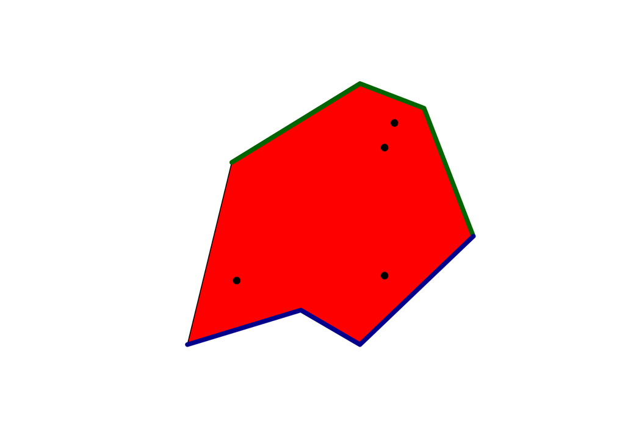

```r
plot(multiple_polygons, col="red")
plot(multiple_lines,col=c("dark green","dark blue"), lw=5, add=T)
plot(pts,pch=19,add=T)
```

Note that while the line is not closed, the polygon is!

## Adding a CRS to the geometric objects

Now let’s focus on the `@proj4string` slots of our spatial geometric objects. This is the attribute that stores information about the coordinate reference system (CRS) in which the coordinates of our point, line or polygon are recorded. There are multiple reasons there is not an obivous good choice for a CRS when storing spatial objects. The surface of the Earth is only roughly a sphere, and depending on the application, we might want more or less sophisticated corrections in modeling its shape. Or the usual lat-lon coordinates are in a spherical coordinate system, therefore, it is not easy to calculate the distance between two points on the surface of the earch. In this case, we use a possible Cartesian projection of this sphere (this is how you can draw the map of the world on a sheet of paper).

For a more detailed description, check out the [documentation](https://rspatial.org/raster/spatial/6-crs.html) of the `sp` package. It also contains a link to the most commonly used projection CRS-es. The CRS definition and the projections are usually contained in some programming libraries: you never have to write them for yourself.

For now, we’ll only use two simple systems: latitudes and longitudes, and a Cartesian projection in which you can measure distances using the easiest Cartesian formulas. The most common projections and CRSs have a so-called [EPSG code](https://en.wikipedia.org/wiki/EPSG_Geodetic_Parameter_Dataset) that simplifies their calls, e.g. the latlon system is 4326, and the [Mercator projection](https://en.wikipedia.org/wiki/Web_Mercator_projection) is 3857.

```r
longitude <- c(-116.7, -120.4, -116.7, -113.5, -115.5, -120.8, -119.5, -113.7, -113.7, -110.7)
latitude <- c(45.3, 42.6, 38.9, 42.1, 35.7, 38.9, 36.2, 39, 41.6, 36.9)
lonlat <- cbind(longitude, latitude)
crsinfo <- sp::CRS("+init=epsg:4326")
pts <- SpatialPoints(lonlat,proj4string = crsinfo)
```

How to we convert between two systems?

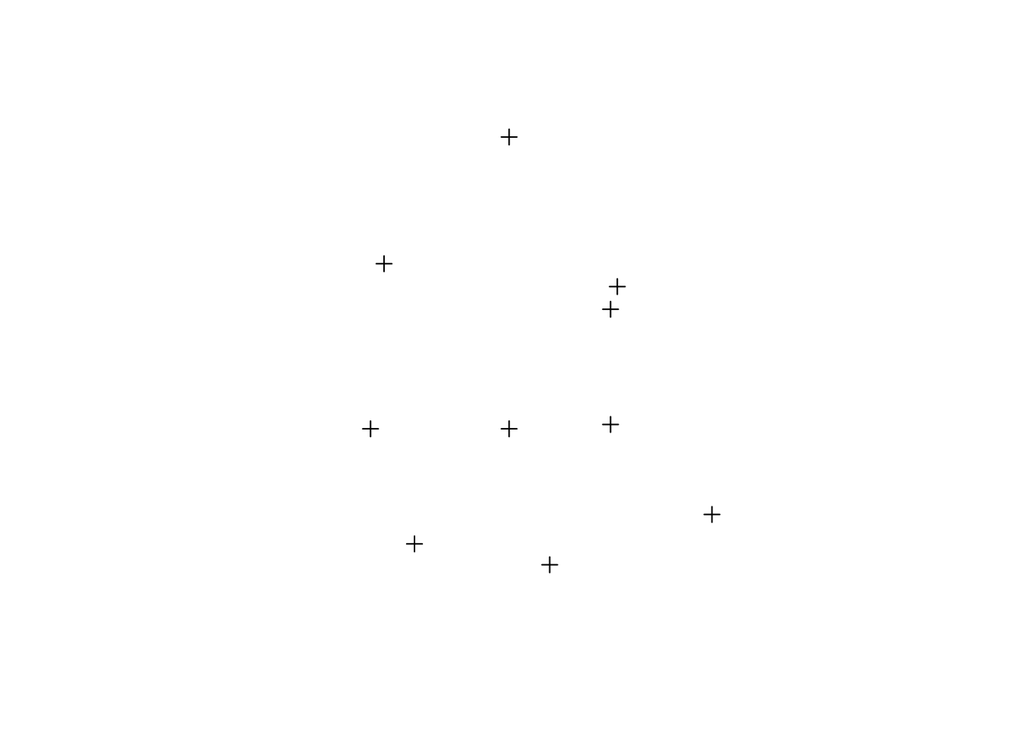

```r
old_crs = CRS("+init=epsg:4326")
new_crs = CRS("+init=epsg:3857")

projected_points = sp::spTransform(pts,new_crs)
plot(projected_points)
```

Note how the relative position of these points barely changed, but the `(x,y)` values are now very different from the original lon-lat positions. The points are now embedded into a Cartesian system, where we can simply measure their distance by using the Pythagorean theorem.

How do we obtain the same projection for `sf` objects?

```r
pts_sf <- st_as_sf(pts) %>% st_transform(new_crs)
pts_sf
```

```
## Simple feature collection with 10 features and 0 fields
## geometry type:  POINT
## dimension:      XY
## bbox:           xmin: -13447390 ymin: 4259420 xmax: -12323070 ymax: 5668875
## CRS:            +init=epsg:3857 +proj=merc +a=6378137 +b=6378137 +lat_ts=0.0 +lon_0=0.0 +x_0=0.0 +y_0=0 +k=1.0 +units=m +nadgrids=@null +no_defs
##                     geometry
## 1  POINT (-12990985 5668875)
## 2  POINT (-13402867 5251285)
## 3  POINT (-12990985 4707358)
## 4  POINT (-12634762 5175971)
## 5  POINT (-12857401 4259420)
## 6  POINT (-13447394 4707358)
## 7  POINT (-13302679 4328176)
## 8  POINT (-12657026 4721672)
## 9  POINT (-12657026 5101248)
## 10 POINT (-12323068 4425177)
```

## Drawing nice interactive maps

If we do the data analysis in R, then it would be convenient to put our data on a map in R, too. There are some libraries that enable the usage of the powerful and lightweight [Leaflet.js](https://leafletjs.com/) library in R In the following cells, we are going to have a look at some basic functionalities of these maps in Folium.

Let’s display the inner city of Budapest!

```r
m <- leaflet::leaflet()
m <- setView(m, lng = 19.05, lat = 47.5, zoom = 13)
m <- addTiles(m)
m
```

[interactive chart not shown]

The map used the tiles of the https://openstreetmap.org freely available database. There are many other options depending on our aims, see https://rstudio.github.io/leaflet/basemaps.html. A rather common approach for example is:

```r
m <- addProviderTiles(m, provider = providers$CartoDB.Positron)
m
```

[interactive chart not shown]

Let’s add some useful objects to our map!

```r
m <-setView(m, lng = 19.05, lat = 47.47, zoom = 14)
m <- addMarkers(m, lng=19.06, lat = 47.47, popup="ELTE")
m
```

[interactive chart not shown]

Which projection does our map use? What bounding box do we see on it?

```r
m$x$options$crs$crsClass
```

```
## [1] "L.CRS.EPSG3857"
```

```r
m$x$limits
```

```
## $lat
## [1] 47.47 47.47
##
## $lng
## [1] 19.06 19.06
```

## Combining data and spatial objects

In most real-life applications, our aim is to combine some kind of data with our spatial objects. E.g. we’d like to color countries according to GDP per capita.

For this, the library `sp` has special dataframe classes, that might contain points, lines or polygons in each row. We are going to try out some simple operations on Hungarian county and highway data. You can download the county dataset from here: https://data2.openstreetmap.hu/hatarok/index.php?admin=6. It contains so-called shapefiles that store the geometric information and the metadata as well.

```r
sdf <- readOGR("./shapes/admin6.shp")
head(sdf)
```

```
##                           NAME ADMIN_LEVE
## 0   Borsod-Abaúj-Zemplén megye          6
## 1 Szabolcs-Szatmár-Bereg megye          6
## 2                    Vas megye          6
## 3                Baranya megye          6
## 4                   Zala megye          6
## 5                 Somogy megye          6
```

```r
class(sdf)
```

```
## [1] "SpatialPolygonsDataFrame"
## attr(,"package")
## [1] "sp"
```

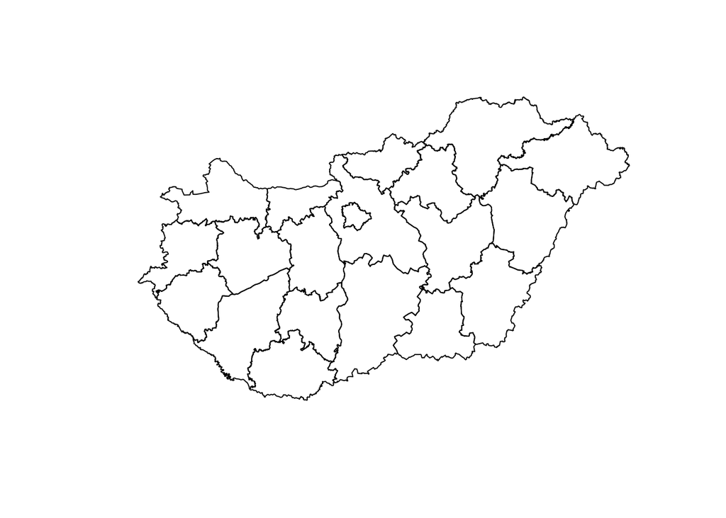

```r
plot(sdf)
```

```r
sdf@data
```

```
##                            NAME ADMIN_LEVE
## 0    Borsod-Abaúj-Zemplén megye          6
## 1  Szabolcs-Szatmár-Bereg megye          6
## 2                     Vas megye          6
## 3                 Baranya megye          6
## 4                    Zala megye          6
## 5                  Somogy megye          6
## 6       Győr-Moson-Sopron megye          6
## 7                Veszprém megye          6
## 8                   Tolna megye          6
## 9             Bács-Kiskun megye          6
## 10                  Fejér megye          6
## 11      Komárom-Esztergom megye          6
## 12                     Budapest          6
## 13                   Pest megye          6
## 14               Csongrád megye          6
## 15                  Békés megye          6
## 16   Jász-Nagykun-Szolnok megye          6
## 17                  Heves megye          6
## 18            Hajdú-Bihar megye          6
## 19                 Nógrád megye          6
```

```r
pest_megye <- sdf@polygons[[14]]
pest_megye@Polygons[[2]]@hole
```

```
## [1] TRUE
```

Or rather as `sf` class, it also works very well with `ggplot`!!!

```r
sdf <- st_read('shapes/admin6.shp') %>% st_transform(new_crs)
head(sdf)
```

```
## Simple feature collection with 6 features and 2 fields
## geometry type:  POLYGON
## dimension:      XY
## bbox:           xmin: 1793790 ymin: 5769001 xmax: 2548961 ymax: 6236894
## CRS:            +init=epsg:3857 +proj=merc +a=6378137 +b=6378137 +lat_ts=0.0 +lon_0=0.0 +x_0=0.0 +y_0=0 +k=1.0 +units=m +nadgrids=@null +no_defs
##                           NAME ADMIN_LEVE                       geometry
## 1   Borsod-Abaúj-Zemplén megye          6 POLYGON ((2232168 6166712, ...
## 2 Szabolcs-Szatmár-Bereg megye          6 POLYGON ((2346477 6139027, ...
## 3                    Vas megye          6 POLYGON ((1793790 5951985, ...
## 4                Baranya megye          6 POLYGON ((1962014 5809256, ...
## 5                   Zala megye          6 POLYGON ((1821481 5937516, ...
## 6                 Somogy megye          6 POLYGON ((1878544 5861666, ...
```

```r
class(sdf)
```

```
## [1] "sf"         "data.frame"
```

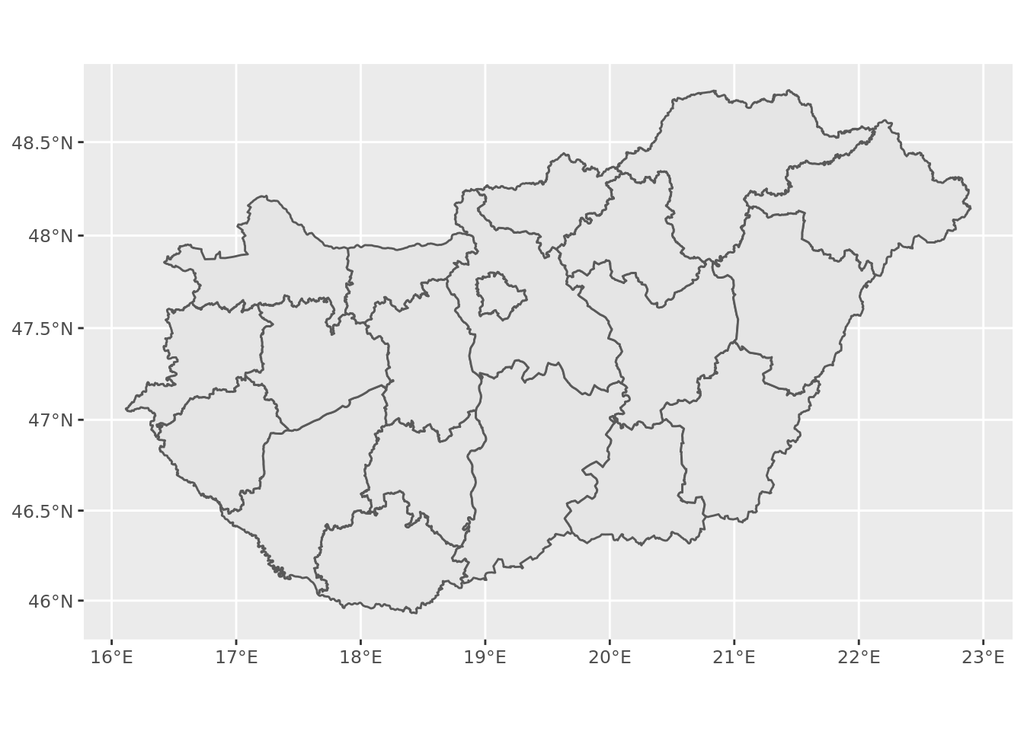

```r
ggplot(sdf) + geom_sf()
```

Leaflet can handle both classes!

```r
#sdf <- readOGR("./shapes/admin6.shp") %>% spTransform(old_crs)
# a very annoying bug!!!
read_sf("./shapes/admin6.shp")
```

```
## Simple feature collection with 20 features and 2 fields
## geometry type:  POLYGON
## dimension:      XY
## bbox:           xmin: 1793790 ymin: 5738323 xmax: 2548961 ymax: 6204779
## CRS:            3785
## # A tibble: 20 x 3
##    NAME             ADMIN_LEVE                                          geometry
##    <chr>            <chr>                                          <POLYGON [m]>
##  1 Borsod-Abaúj-Ze… 6          ((2232168 6134803, 2232284 6134975, 2232300 6135…
##  2 Szabolcs-Szatmá… 6          ((2346477 6107200, 2346482 6107391, 2346547 6107…
##  3 Vas megye        6          ((1793790 5920727, 1793969 5920931, 1794029 5920…
##  4 Baranya megye    6          ((1962014 5778448, 1962317 5778514, 1962498 5778…
##  5 Zala megye       6          ((1821481 5906303, 1821599 5906431, 1821785 5906…
##  6 Somogy megye     6          ((1878544 5830691, 1878570 5831044, 1878598 5831…
##  7 Győr-Moson-Sopr… 6          ((1828037 6051354, 1828067 6051376, 1828109 6051…
##  8 Veszprém megye   6          ((1900620 5950390, 1900674 5950703, 1900671 5950…
##  9 Tolna megye      6          ((2003944 5844769, 2004189 5844710, 2004798 5845…
## 10 Bács-Kiskun meg… 6          ((2085356 5787636, 2085962 5788188, 2086326 5788…
## 11 Fejér megye      6          ((2007561 5997801, 2007994 5998057, 2008363 5998…
## 12 Komárom-Eszterg… 6          ((1989373 6017209, 1989433 6017336, 1989496 6017…
## 13 Budapest         6          ((2106733 6031349, 2107188 6031590, 2107278 6031…
## 14 Pest megye       6          ((2080398 6036809, 2081055 6037594, 2081084 6037…
## 15 Csongrád megye   6          ((2186113 5822827, 2186915 5823864, 2187780 5825…
## 16 Békés megye      6          ((2271753 5919176, 2272129 5919541, 2272444 5919…
## 17 Jász-Nagykun-Sz… 6          ((2187584 6034324, 2188030 6034798, 2188314 6036…
## 18 Heves megye      6          ((2178649 6062879, 2179349 6063631, 2180231 6064…
## 19 Hajdú-Bihar meg… 6          ((2318134 6047283, 2318275 6047518, 2318529 6050…
## 20 Nógrád megye     6          ((2107062 6116363, 2107091 6116335, 2107099 6116…
```

```r
# if we don't set the crs by hand, it'll shift the polygons to the north
sdf <- read_sf("./shapes/admin6.shp", crs = 3785) %>% st_transform(old_crs)
hungary <- leaflet(sdf) %>%
  addTiles() %>%
  addPolygons(
    color = "#444444",
    weight = 3,
    smoothFactor = 0.5,
    highlightOptions = highlightOptions(
      fillColor = "#ffffff",
      fillOpacity=1,
      weight = 5,
      bringToFront = TRUE
    )
  )
```

Do these shapes give us the total area of Hungary (~93000 km^2)?

```r
sum(st_area(sdf))/1e6
```

```
## 93012.66 [m^2]
```

Which is the biggest county?

```r
as.character(sdf$NAME[which.max(st_area(sdf))])
```

```
## [1] "Bács-Kiskun megye"
```

Let us create a list of neighboring counties.

```r
sdf_buffered <- st_read("./shapes/admin6.shp") %>% st_buffer(500)
sdf_intersections <- st_intersects(sdf_buffered,sdf_buffered)
sdf[sdf_intersections[[1]],]
```

```
## Simple feature collection with 6 features and 2 fields
## geometry type:  POLYGON
## dimension:      XY
## bbox:           xmin: 18.92806 ymin: 46.75467 xmax: 22.89771 ymax: 48.58526
## CRS:            +init=epsg:4326 +proj=longlat +datum=WGS84 +no_defs +ellps=WGS84 +towgs84=0,0,0
## # A tibble: 6 x 3
##   NAME             ADMIN_LEVE                                           geometry
##   <chr>            <chr>                                           <POLYGON [°]>
## 1 Borsod-Abaúj-Ze… 6          ((20.05191 48.16772, 20.05295 48.16875, 20.05309 …
## 2 Szabolcs-Szatmá… 6          ((21.07876 48.00208, 21.0788 48.00322, 21.07939 4…
## 3 Jász-Nagykun-Sz… 6          ((19.6514 47.56218, 19.65541 47.56505, 19.65796 4…
## 4 Heves megye      6          ((19.57113 47.73499, 19.57743 47.73953, 19.58535 …
## 5 Hajdú-Bihar meg… 6          ((20.82415 47.64067, 20.82542 47.6421, 20.8277 47…
## 6 Nógrád megye     6          ((18.92806 48.05712, 18.92832 48.05695, 18.92839 …
```

Now let’s try combining two spatial dataframes! We’ll use the railway map of Hungary obtained from OpenStreetMap!

```r
railways <- st_read('./shapes/gis.osm_railways_free_1.shp',crs=4326)
head(railways)
```

```
## Simple feature collection with 6 features and 4 fields
## geometry type:  LINESTRING
## dimension:      XY
## bbox:           xmin: 17.98549 ymin: 46.0331 xmax: 19.84149 ymax: 48.25984
## CRS:            EPSG:4326
##    osm_id code fclass name                       geometry
## 1 4292868 6101   rail <NA> LINESTRING (17.99069 46.033...
## 2 4293011 6101   rail <NA> LINESTRING (18.1048 46.2296...
## 3 4351791 6101   rail <NA> LINESTRING (18.08725 47.759...
## 4 4351792 6101   rail <NA> LINESTRING (18.08664 47.754...
## 5 4418653 6101   rail <NA> LINESTRING (19.80227 48.100...
## 6 4418654 6101   rail <NA> LINESTRING (19.83676 48.259...
```

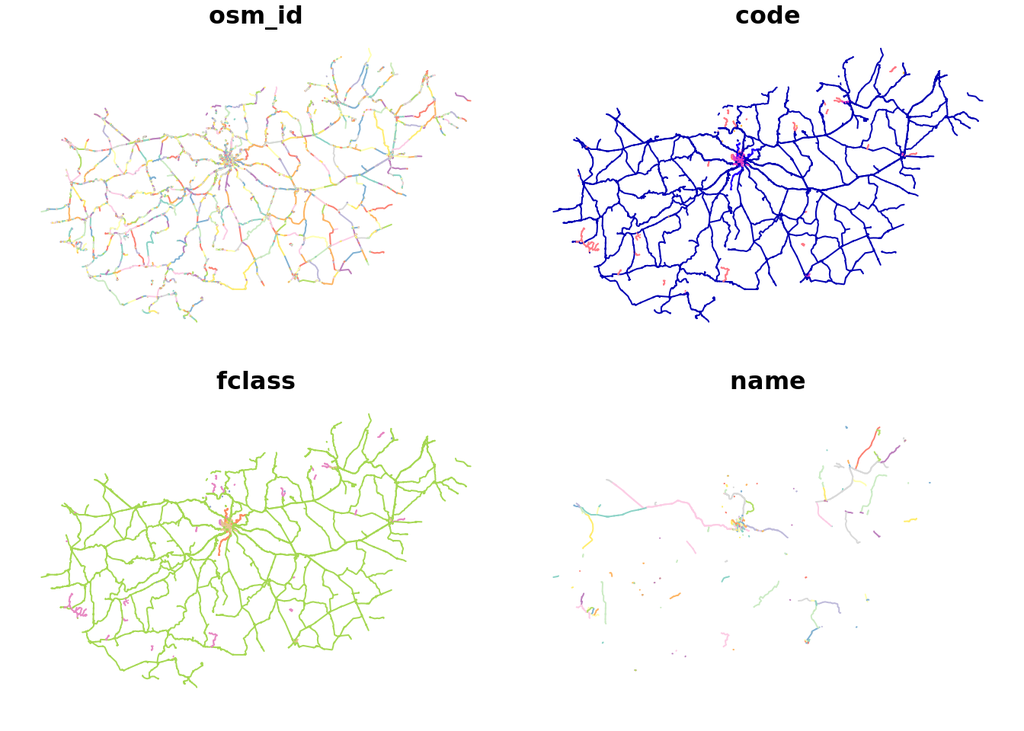

```r
plot(railways)
```

```r
project_crs = CRS("+init=epsg:3395")

sdf <- sdf %>% st_transform(project_crs)
railways <- railways %>% st_transform(project_crs)
```

A possible sensible question:

Which county has the longest railway network in Hungary?

It is important from here on to use `sf`, since it builds [spatial indices](https://gistbok.ucgis.org/bok-topics/spatial-indexing) before any spatial joins, which is crucial for efficiency.

See https://insileco.github.io/2017/09/12/efficiency-of-spatial-intersects-in-r/ for example.

```r
railways_to_counties = data.frame(st_intersects(railways,sdf))
colnames(railways_to_counties) <- c("id","county.id")
railways <- railways[railways_to_counties$id,]
railways$county.id <- railways_to_counties$county.id
railways$length = st_length(railways)
county_lengths <-
  data.frame(railways) %>%
    group_by(county.id) %>%
    summarise(total_length=sum(length)/1000) %>%
    arrange(desc(total_length))
county_lengths$name = sdf[county_lengths$county.id,]$NAME
head(county_lengths,3)
```

```
## # A tibble: 3 x 3
##   county.id total_length name
##       <int>          [m] <chr>
## 1        13     2134.531 Budapest
## 2        14     2005.123 Pest megye
## 3         2     1608.307 Szabolcs-Szatmár-Bereg megye
```

## A very important format: GeoJSON

GeoJSON is a very flexible exchange format in the 4326 coordinate system used by numerous applications and services. It is very much portable, and therefore, useful to know its structure.

- If you already know what a JSON file is, stop reading, this is only a nested JSON with special keys.
- If you know what a Python dictionary is, stop reading, a GeoJSON is a special dictionary with preset keys and specified value types represented as a text.
- If you know how to build a webpage, you can assume that a GeoJSON is like an HTML: there is a nested structure of labelled elements, where “tags” are called keys, and the HTML content under a certain tag is a value.
- If you still have no clue, here’s an example:

```r
library(geojsonR)

str_js = '{ "type": "MultiPolygon",
            "coordinates": [
                [[[102.0, 2.0], [103.0, 2.0], [103.0, 3.0], [102.0, 3.0], [102.0, 2.0]]],
                [[[100.0, 0.0], [101.0, 0.0], [101.0, 1.0], [100.0, 1.0], [100.0, 0.0]],
                 [[100.2, 0.2], [100.8, 0.2], [100.8, 0.8], [100.2, 0.8], [100.2, 0.2]]]
                ]
}'


char_js = FROM_GeoJson(url_file_string = str_js)

char_js
```

```
## $type
## [1] "MultiPolygon"
##
## $coordinates
## $coordinates[[1]]
##      [,1] [,2]
## [1,]  102    2
## [2,]  103    2
## [3,]  103    3
## [4,]  102    3
## [5,]  102    2
##
## $coordinates[[2]]
## $coordinates[[2]][[1]]
##      [,1] [,2]
## [1,]  100    0
## [2,]  101    0
## [3,]  101    1
## [4,]  100    1
## [5,]  100    0
##
## $coordinates[[2]][[2]]
##       [,1] [,2]
## [1,] 100.2  0.2
## [2,] 100.8  0.2
## [3,] 100.8  0.8
## [4,] 100.2  0.8
## [5,] 100.2  0.2
```

```
calif <- leaflet() %>% fitBounds(-124.48,32.53,-114.13,42.01) %>% addTiles() %>% addGeoJSON(paste0(readLines("https://raw.githubusercontent.com/mlampros/DataSets/master/california.geojson"),collapse=""))
calif
```

# Exercises

[John Snow](https://en.wikipedia.org/wiki/John_Snow) was an English physician, who was first to trace the source of a cholera outbreak in London’s Soho district in 1854 using data visualization. In the following exercises, we are going to reconstruct the map of Snow with modern tools.

[figure not shown]

Though there is a whole [R library](https://vincentarelbundock.github.io/Rdatasets/doc/HistData/Snow.pumps.html) dedicated to this dataset, we would like R users to also build the solutions (e.g. Voronoi cells) from scratch.

Further reading: * https://en.wikipedia.org/wiki/1854_Broad_Street_cholera_outbreak * https://www1.udel.edu/johnmack/frec682/cholera/cholera2.html * https://www.theguardian.com/news/datablog/interactive/2013/mar/15/cholera-map-john-snow-recreated

The shapefile that will be used in these exercises are located at http://donboyes.com/2011/10/14/john-snow-and-serendipity/, but they are already downloaded into the shapes directory.

## Exercise 1

Load the death and the pump dataset into a tabular format! Have a look at the dataset’s structure! The pump dataset contains the locations of wells, that were used to obtain water for drinking, cooking etc.

*It is sometimes worth to have a look at a shapefile’s content quickly. For Linux, [QGIS](https://www.qgis.org/en/site/about/index.html) is a powerful free GIS system, try it at home!*

## Exercise 2

Extract the latitudes and the longitudes for each row in both datasets as additional columns!

The ‘X’ and ‘Y’ columns are coordinates in an arbitrary coordinate system and usually not part of a *shp* file.

Project your points into a coordinate system where you can measure real distances, then create a meaningful visualization of the data!

## Exercise 3

How many deaths were within a given radius around the wells? Test for a series of radiuses. Visualize your results!

## Exercise 4

Put both the deaths and the pumps on a zoomable Leaflet map that has a base layer from a tile server different from that of the default settings of your chosen method. Set the appropriate map center and zoom level. Use different markers for the deaths and the pumps datasets.

## Exercise 5

Calculate the Voronoi cells for the pumps, and count the number of deaths falling into each of the cells. Create a bar chart of the number of deaths in each cell. Pinpoint the possible source of the infection.

*Store the Voronoi cells in an sf object, then you can easily do a spatial join (e.g. testing whether a polygon in the Voronoi dataframe contains a point from the death dataframe).*

## Exercise 6

Put the Voronoi cells on the map, colored according to the number of deaths (like on a heatmap/create a so-called choropleth).